# Spark Machine learning

### Learning goals:

- align the relationships between Hadoop, Spark, and Databricks
- differentiate between Spark RDDs and Spark Dataframes and when each is appropriate
- locate and explore the Spark.ML documentation
- code along a text classification problem using four different ml algorithms, a data prep pipeline, and gridsearch to fine tune a model

# Spark context and concepts review

[figure not shown]

# The story of Spark (in diagrams)

## Start with Hadoop

[figure not shown]

[diagram source](https://sites.google.com/site/codingbughunter/hadoop/yarn-general-discribe)

## Yarn facilitates the resource allocation between Spark and the HDFS

### YARN = Yet Another Resource Negotiator

#### YARN is a subproduct of Hadoop

[figure not shown]

[diagram source](https://sites.google.com/site/codingbughunter/hadoop/yarn-general-discribe)

## Then visualize the Spark ecosystem built on top of that

[figure not shown]

[image source here](https://databricks.com/spark/about)

## Databricks provides wrap around services around *that*

[figure not shown]

[diagram source](https://verify.wiki/wiki/Databricks)

# The story of Spark (a timeline)

| Date | Product | Update |
| --- | --- | --- |
| 2002 | Hadoop | Doug Cutting starts `Apache Nutch` researching sort/merge processing |
| 2006 | Hadoop | Leaves `Nutch` and joins `Yahoo`, renaming the project `Hadoop` |
| 2008 | Hadoop | `Hadoop` was made `Apache’s` top level project |
| Jan 2008 | Hadoop | v 0.10.1 released |
| 2009 | Spark | started as a research project at the UC Berkeley AMPLab |
| 2010 | Spark | open sourced |
| Sept 2012 | Spark | 0.6.0 released |
| 2013 | Spark | moved to the `Apache` Software Foundation |
| Feb 2013 | Spark | Spark 0.7 adds a Python API called `PySpark` |
| Sept 2013 | Spark | 0.8.0 introduces `MLlib` |
| 2013 | Databricks | Original Spark research team at UC Berkeley found Databricks |
| May 2014 | Spark | v 1.0 introduces Spark SQL, for loading and manipulating structured data in Spark |
| Sept 2014 | Spark | v 1.1.0 provided support for registering Python lambda funtions as UDFs |
| Mar 2015 | Spark | v 1.3.0 brings a new DataFrame API |
| Jun 2015 | Spark | v 1.4.0 brings an R API to Spark |
| 2015 | Databricks | The Databricks Apache Spark cloud platform goes public |
| Jan 2016 | Spark | v 1.6.0 brings a new Dataset API - A new Spark API, similar to RDDs, that allows users to work with custom objects and lambda functions while still gaining the benefits of the Spark SQL execution engi… |
| Jul 2016 | Spark | v 2.0.0 **big update**! - Unifying DataFrame and Dataset: In Scala and Java, DataFrame and Dataset have been unified, i.e. DataFrame is just a type alias for Dataset of Row. In Python and R, given the… |
| 2016 | Databricks | Databricks Launches Free Community Edition As Companion To Free Online Spark Courses |
| Jul 2017 | Spark | v 2.2.0 drops support for Python 2.6 |
| Nov 2018 | Spark | v 2.4.0 - This release adds Barrier Execution Mode for better integration with deep learning frameworks - more integration between pandas UDF and spark DataFrames |

# Spark data objects

[figure not shown]

## In Pyspark there are only RDD and DataFrames

In other languages where "compiling" is done, there is the distinction between DataFrames and DataSet.

[figure not shown]

## Differences between objects:

[figure not shown]

### Use an RDD when:

[quoted from databricks](https://databricks.com/blog/2016/07/14/a-tale-of-three-apache-spark-apis-rdds-dataframes-and-datasets.html)

> - you want low-level transformation and actions and control on your dataset;
> - your data is unstructured, such as media streams or streams of text;
> - you want to manipulate your data with functional programming constructs than domain specific expressions;
> - you don’t care about imposing a schema, such as columnar format, while processing or accessing data attributes by name or column

### Use a dataframe when:

[also quoted from databricks](https://databricks.com/blog/2016/07/14/a-tale-of-three-apache-spark-apis-rdds-dataframes-and-datasets.html)

> - you want rich semantics, high-level abstractions, and domain specific APIs, use DataFrame
> - your processing demands high-level expressions, filters, maps, aggregation, averages, sum, SQL queries, columnar access and use of lambda functions on semi-structured data, use DataFrame
> - you want higher degree of type-safety at compile time, want typed JVM objects, take advantage of Catalyst optimization, and benefit from Tungsten’s efficient code generation, use Dataset.
> - you want unification and simplification of APIs across Spark Libraries, use DataFrame or Dataset.
> - If you are a R user, use DataFrames.
> - If you are a Python user, use DataFrames and resort back to RDDs if you need more control.

**Note**: Machine learning algorithms are run on *DataFrames*

## Review:

- You are grabbing live tweets about the CW show 'Jane the Virgin' for later analysis. In the Spark ecosystem, where should you store them? an RDD or a DataFrame?
- You have an RDD of data that you wish to use to build a predictive model. Should you leave it as an RDD or transform it to a DataFrame?

# Machine learning in Spark

Section influenced by [this analysis of twitter data](https://wesslen.github.io/twitter/predicting_twitter_profile_location_with_pyspark/)

## The return of Greg

[figure not shown]

## Greg's life is full of pain

Greg has become really tired of his boss asking him to do all these random things.  
**First** she had him learn Object Oriented Programming and it's been down hill ever since.  
**Now** she's wanting him to send her a summary of political news from the BBC each day.  
The problem is it takes him hours just to sort through the BBC website to get *just* the political articles that interest her.

## But wait!

What if rather than sorting through them himself he could build a classification model that will sort only the ones he needs?

### Create spark context

```python
import pyspark
spark = pyspark.sql.SparkSession.builder.getOrCreate()
sc = spark.sparkContext
```

```python
spark
```

**SparkSession - in-memory**

**SparkContext**

[Spark UI](http://192.168.1.9:4041)

**Version**

`v2.4.3`

**Master**

`local[*]`

**AppName**

`pyspark-shell`

```python
sc
```

**SparkContext**

[Spark UI](http://192.168.1.9:4041)

**Version**

`v2.4.3`

**Master**

`local[*]`

**AppName**

`pyspark-shell`

### Read in our dataset of articles

```python
bbc = spark.read.csv(path='bbc-text.csv',sep=',',encoding='UTF-8', header=True,inferSchema=True)
```

```python
def show(df, n=5):
    return df.limit(n).toPandas()
```

### Do some basic data exploration

```python
bbc.columns
```

```
['category', 'text']
```

```python
bbc.dtypes
```

```
[('category', 'string'), ('text', 'string')]
```

```python
bbc.printSchema()
```

```
root
 |-- category: string (nullable = true)
 |-- text: string (nullable = true)
```

```python
bbc.limit(10).toPandas()
```

|  | category | text |
| --- | --- | --- |
| 0 | tech | tv future in the hands of viewers with home th... |
| 1 | business | worldcom boss left books alone former worldc... |
| 2 | sport | tigers wary of farrell gamble leicester say ... |
| 3 | sport | yeading face newcastle in fa cup premiership s... |
| 4 | entertainment | ocean s twelve raids box office ocean s twelve... |
| 5 | politics | howard hits back at mongrel jibe michael howar... |
| 6 | politics | blair prepares to name poll date tony blair is... |
| 7 | sport | henman hopes ended in dubai third seed tim hen... |
| 8 | sport | wilkinson fit to face edinburgh england captai... |
| 9 | entertainment | last star wars not for children the sixth an... |

```python
bbc.count()
```

```
2225
```

```python
bbc.groupBy('category').count().show()
```

```
+-------------+-----+
|     category|count|
+-------------+-----+
|        sport|  511|
|     politics|  417|
|entertainment|  386|
|     business|  510|
|         tech|  401|
+-------------+-----+
```

```python
# Create a new column of target "politics"
from pyspark.sql.functions import when, col
bbc = bbc.withColumn("label", \
                           (when(col("category").like("%politics%"), 1) \
                           .otherwise(0)))
```

```python
# drop original target column
bbc = bbc.drop(bbc.category)
```

```python
show(bbc,10)
```

|  | text | label |
| --- | --- | --- |
| 0 | tv future in the hands of viewers with home th... | 0 |
| 1 | worldcom boss left books alone former worldc... | 0 |
| 2 | tigers wary of farrell gamble leicester say ... | 0 |
| 3 | yeading face newcastle in fa cup premiership s... | 0 |
| 4 | ocean s twelve raids box office ocean s twelve... | 0 |
| 5 | howard hits back at mongrel jibe michael howar... | 1 |
| 6 | blair prepares to name poll date tony blair is... | 1 |
| 7 | henman hopes ended in dubai third seed tim hen... | 0 |
| 8 | wilkinson fit to face edinburgh england captai... | 0 |
| 9 | last star wars not for children the sixth an... | 0 |

## Machine LEarning in Spark

Spark's [documentation](https://spark.apache.org/docs/2.2.0/ml-guide.html#mllib-main-guide) is fairly straight forward! Let's take a look. It shouldn't look *too* different than `sklearn`

### Data prep pipeline

```python
from pyspark.ml.feature import RegexTokenizer, StopWordsRemover, CountVectorizer


# regular expression tokenizer
regexTokenizer = RegexTokenizer(inputCol="text", outputCol="words", pattern="\\W")

# stop words
add_stopwords = ["http","https","amp","rt","t","c","can"] # standard stop words
stopwordsRemover = StopWordsRemover(inputCol="words", outputCol="filtered").setStopWords(add_stopwords)

# bag of words count
countVectors = CountVectorizer(inputCol="filtered", outputCol="features", vocabSize=10000, minDF=5)
```

```python
from pyspark.ml import Pipeline

pipeline = Pipeline(stages=[regexTokenizer, stopwordsRemover, countVectors])

# Fit the pipeline to training documents.
pipelineFit = pipeline.fit(bbc)
dataset = pipelineFit.transform(bbc)
```

```python
(trainingData, testData) = dataset.randomSplit([0.7, 0.3], seed = 100)
print("Training Dataset Count: " + str(trainingData.count()))
print("Test Dataset Count: " + str(testData.count()))
```

```
Training Dataset Count: 1561
Test Dataset Count: 664
```

### Logistic Regression

```python
from pyspark.ml.classification import LogisticRegression
# Build the model
lr = LogisticRegression(maxIter=20, regParam=0.3, elasticNetParam=0, family = "binomial")

# Train model with Training Data
lrModel = lr.fit(trainingData)
```

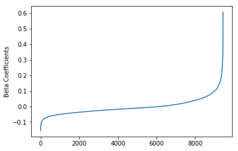

```python
import matplotlib.pyplot as plt
%matplotlib inline
import numpy as np

beta = np.sort(lrModel.coefficients)

plt.plot(beta)
plt.ylabel('Beta Coefficients')
plt.show()
```

### Summary has many components one can call

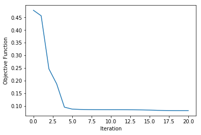

```python
# Extract the summary from the returned LogisticRegressionModel instance trained
trainingSummary = lrModel.summary

# Obtain the objective per iteration
objectiveHistory = trainingSummary.objectiveHistory
plt.plot(objectiveHistory)
plt.ylabel('Objective Function')
plt.xlabel('Iteration')
plt.show()
```

```
areaUnderROC: 0.9999318102470105
```

[figure not shown]

```python
# Obtain the receiver-operating characteristic as a dataframe and areaUnderROC.
print("areaUnderROC: " + str(trainingSummary.areaUnderROC))

#trainingSummary.roc.show(n=10, truncate=15)
roc = trainingSummary.roc.toPandas()
plt.plot(roc['FPR'],roc['TPR'])
plt.ylabel('False Positive Rate')
plt.xlabel('True Positive Rate')
plt.title('ROC Curve')
plt.show()
```

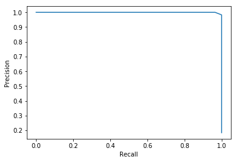

```python
pr = trainingSummary.pr.toPandas()
plt.plot(pr['recall'],pr['precision'])
plt.ylabel('Precision')
plt.xlabel('Recall')
plt.show()
```

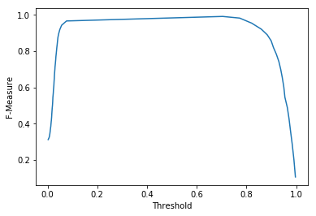

```python
# Set the model threshold to maximize F-Measure
#trainingSummary.fMeasureByThreshold.show(n=10, truncate = 15)
f = trainingSummary.fMeasureByThreshold.toPandas()
plt.plot(f['threshold'],f['F-Measure'])
plt.ylabel('F-Measure')
plt.xlabel('Threshold')
plt.show()
```

### Evaluate on test data

```python
# Make predictions on test data using the transform() method.
# LogisticRegression.transform() will only use the 'features' column.
predictions = lrModel.transform(testData)

predictions.select("text","probability").show(n=10, truncate=40)
```

```
+----------------------------------------+----------------------------------------+
|                                    text|                             probability|
+----------------------------------------+----------------------------------------+
|2d metal slug offers retro fun like s...|[0.9804110787644088,0.019588921235591...|
|a year to remember for irish there us...|[0.9971249956337924,0.002875004366207...|
|a-listers flock to gervais sitcom hol...|[0.9802504324750114,0.019749567524988...|
|aaliyah claim dismissed by court late...|[0.9607748047895676,0.039225195210432...|
|actress roberts takes spider role act...|[0.9728119265594252,0.027188073440574...|
|adventure tale tops awards young book...|[0.9765669471450196,0.02343305285498057]|
|african double in edinburgh world 500...|[0.9705370095883613,0.029462990411638...|
|aids and climate top davos agenda cli...| [0.4551814729453956,0.5448185270546043]|
|ajax refuse to rule out jol move ajax...|[0.9810804181561628,0.01891958184383711]|
|alfa romeos  to get gm engines  fiat ...|[0.9471905771345529,0.05280942286544703]|
+----------------------------------------+----------------------------------------+
only showing top 10 rows
```

#### Prediction object is a dataframe

with some options

```python
predictions.printSchema()
```

```
root
 |-- text: string (nullable = true)
 |-- label: integer (nullable = false)
 |-- words: array (nullable = true)
 |    |-- element: string (containsNull = true)
 |-- filtered: array (nullable = true)
 |    |-- element: string (containsNull = true)
 |-- features: vector (nullable = true)
 |-- rawPrediction: vector (nullable = true)
 |-- probability: vector (nullable = true)
 |-- prediction: double (nullable = false)
```

```python
predictions.filter(predictions['prediction'] == 1) \
    .select("text","probability","label","prediction") \
    .orderBy("probability", ascending=False) \
    .show(n = 20, truncate = 30)
```

```
+------------------------------+------------------------------+-----+----------+
|                          text|                   probability|label|prediction|
+------------------------------+------------------------------+-----+----------+
|uk youth  interested  in po...|[0.49201168647571,0.5079883...|    1|       1.0|
|nuclear dumpsite  plan atta...|[0.4873060249997719,0.51269...|    1|       1.0|
|end bush  denial  blair tel...|[0.4699202484721028,0.53007...|    1|       1.0|
|tory  stalking horse  meyer...|[0.4675499884893324,0.53245...|    1|       1.0|
|labour trio  had vote-rig f...|[0.466123733286589,0.533876...|    1|       1.0|
|aids and climate top davos ...|[0.4551814729453956,0.54481...|    0|       1.0|
|games enter the classroom v...|[0.451182251720878,0.548817...|    0|       1.0|
|uk  needs true immigration ...|[0.4504281900970625,0.54957...|    1|       1.0|
|few ready  for information ...|[0.4438001630983848,0.55619...|    1|       1.0|
|kennedy predicts bigger tur...|[0.4402414376855856,0.55975...|    1|       1.0|
|former ni minister scott di...|[0.42412133099041865,0.5758...|    1|       1.0|
|brown visits slum on africa...|[0.4175235584517576,0.58247...|    1|       1.0|
|bid to cut court witness st...|[0.4119410001340319,0.58805...|    1|       1.0|
|blair hails turkey-eu talks...|[0.40900799518871295,0.5909...|    1|       1.0|
|parents face video game les...|[0.4063363108393201,0.59366...|    0|       1.0|
|jamieson issues warning to ...|[0.39279565260894456,0.6072...|    1|       1.0|
|baa support ahead of court ...|[0.37812777289637317,0.6218...|    1|       1.0|
|no-one can define new hunt ...|[0.35742565406167986,0.6425...|    1|       1.0|
|parties warned over  grey v...|[0.3486324259370026,0.65136...|    1|       1.0|
|hague s six-figure earnings...|[0.3472718718045249,0.65272...|    1|       1.0|
+------------------------------+------------------------------+-----+----------+
only showing top 20 rows
```

```python
from pyspark.ml.evaluation import BinaryClassificationEvaluator
print("Training: Area Under ROC: " + str(trainingSummary.areaUnderROC))

# Evaluate model
evaluator = BinaryClassificationEvaluator(rawPredictionCol="rawPrediction")
print("Test: Area Under ROC: " + str(evaluator.evaluate(predictions, {evaluator.metricName: "areaUnderROC"})))
```

```
Training: Area Under ROC: 0.9999318102470105
Test: Area Under ROC: 0.9947692530609287
```

### Naive Bayes

#### Specify and fit the model

```python
from pyspark.ml.classification import NaiveBayes

# create the trainer and set its parameters
nb = NaiveBayes(smoothing=1, modelType="multinomial")

# train the model
model = nb.fit(trainingData)
```

#### Evaluate Naive Bayes

```python
# select example rows to display.
predictions = model.transform(testData)
predictions.filter(predictions['prediction'] == 1) \
    .select("text","probability","label","prediction") \
    .orderBy("probability", ascending=False) \
    .show(n = 20, truncate = 30)

# compute accuracy on the test set
evaluator = BinaryClassificationEvaluator(rawPredictionCol="prediction")
print("Test: Area Under ROC: " + str(evaluator.evaluate(predictions, {evaluator.metricName: "areaUnderROC"})))
```

```
+------------------------------+------------------------------+-----+----------+
|                          text|                   probability|label|prediction|
+------------------------------+------------------------------+-----+----------+
|world leaders gather to fac...|[0.3234856203600564,0.67651...|    0|       1.0|
|uganda bans vagina monologu...|[0.08546930870003139,0.9145...|    0|       1.0|
|pension hitch for long-livi...|[0.07509543148569661,0.9249...|    0|       1.0|
|sa unveils  more for all  b...|[0.0028957497589554115,0.99...|    0|       1.0|
|parents face video game les...|[0.002311431605911251,0.997...|    0|       1.0|
|cuba winds back economic cl...|[8.61739026907016E-5,0.9999...|    0|       1.0|
|uk helps raped rwandan wome...|[2.5209046203289186E-5,0.99...|    1|       1.0|
|eu aiming to fuel developme...|[1.5309069683180838E-5,0.99...|    0|       1.0|
|mp attacked by muggers in k...|[6.8491185912420155E-6,0.99...|    1|       1.0|
|bush to outline  toughest  ...|[2.888412142065632E-6,0.999...|    0|       1.0|
|sport betting rules in spot...|[4.142862335782538E-7,0.999...|    1|       1.0|
|georgia plans hidden asset ...|[1.2318992015590394E-9,0.99...|    0|       1.0|
|msps hear renewed climate w...|[2.1428143748956225E-10,0.9...|    1|       1.0|
|talks held on gibraltar s f...|[8.185096803923757E-11,0.99...|    1|       1.0|
|e-university  disgraceful w...|[5.253645340008917E-14,0.99...|    1|       1.0|
|parliament s record of scan...|[2.0511178399331492E-14,0.9...|    1|       1.0|
|aids and climate top davos ...|[6.280223580282484E-15,0.99...|    0|       1.0|
|tsunami debt deal to be ann...|   [7.177143120304127E-17,1.0]|    1|       1.0|
|david blunkett in quotes da...|  [1.4398554329371304E-17,1.0]|    1|       1.0|
|jamieson issues warning to ...|   [3.434484719922571E-18,1.0]|    1|       1.0|
+------------------------------+------------------------------+-----+----------+
only showing top 20 rows

Test: Area Under ROC: 0.9850467289719625
```

### Decision Tree

#### Fit model

```python
from pyspark.ml.classification import DecisionTreeClassifier

# Create initial Decision Tree Model
dt = DecisionTreeClassifier(labelCol="label", featuresCol="features", maxDepth=3)

# Train model with Training Data
dtModel = dt.fit(trainingData)
```

```python
print("numNodes = ", dtModel.numNodes)
print( "depth = ", dtModel.depth)
```

```
numNodes =  13
depth =  3
```

#### Evaluate Decision Tree

```python
predictions = dtModel.transform(testData)

predictions.filter(predictions['prediction'] == 0) \
    .select("text","probability","label","prediction") \
    .orderBy("probability", ascending=False) \
    .show(n = 10, truncate = 30)
```

```
+------------------------------+------------------------------+-----+----------+
|                          text|                   probability|label|prediction|
+------------------------------+------------------------------+-----+----------+
|custody death rate  shocks ...|                     [1.0,0.0]|    1|       0.0|
|car giant hit by mercedes s...|[0.9397865853658537,0.06021...|    0|       0.0|
|download chart debut is del...|[0.9397865853658537,0.06021...|    0|       0.0|
|cabs collect mountain of mo...|[0.9397865853658537,0.06021...|    0|       0.0|
|apple sues to stop product ...|[0.9397865853658537,0.06021...|    0|       0.0|
|camera phones are  must-hav...|[0.9397865853658537,0.06021...|    0|       0.0|
|bank voted 8-1 for no rate ...|[0.9397865853658537,0.06021...|    0|       0.0|
|camera phones are  must-hav...|[0.9397865853658537,0.06021...|    0|       0.0|
|battered dollar hits anothe...|[0.9397865853658537,0.06021...|    0|       0.0|
|campbell rescues arsenal so...|[0.9397865853658537,0.06021...|    0|       0.0|
+------------------------------+------------------------------+-----+----------+
only showing top 10 rows
```

```python
# Evaluate model
evaluator = BinaryClassificationEvaluator(rawPredictionCol="rawPrediction")
print("Test: Area Under ROC: " + str(evaluator.evaluate(predictions, {evaluator.metricName: "areaUnderROC"})))
```

```
Test: Area Under ROC: 0.615598058393103
```

### Random Forest

#### Specify model

```python
from pyspark.ml.classification import RandomForestClassifier

# Create an initial RandomForest model.
rf = RandomForestClassifier(labelCol="label", \
                            featuresCol="features", \
                            numTrees = 100, \
                            maxDepth = 4, \
                            maxBins = 32)

# Train model with Training Data
rfModel = rf.fit(trainingData)
```

#### Score and evaluate Random Forest

```python
# Score test Data
predictions = rfModel.transform(testData)

predictions.filter(predictions['prediction'] == 1) \
    .select("text","probability","label","prediction") \
    .orderBy("probability", ascending=False) \
    .show(n = 10, truncate = 30)
```

```
+------------------------------+------------------------------+-----+----------+
|                          text|                   probability|label|prediction|
+------------------------------+------------------------------+-----+----------+
|campaign  cold calls  quest...|[0.4958314785415613,0.50416...|    1|       1.0|
|taxes must be trusted - ken...|[0.49116277553267557,0.5088...|    1|       1.0|
|terror suspects face house ...|[0.4908789792983685,0.50912...|    1|       1.0|
|campbell: e-mail row  silly...|[0.48970460590865306,0.5102...|    1|       1.0|
|police chief backs drinking...|[0.4879246415424786,0.51207...|    1|       1.0|
|women mps reveal sexist tau...|[0.4876432046251011,0.51235...|    1|       1.0|
|uk heading wrong way  says ...|[0.4854414893871376,0.51455...|    1|       1.0|
|election deal faltered over...|[0.48447641465335833,0.5155...|    1|       1.0|
|howard attacks  pay later  ...|[0.4801001249816656,0.51989...|    1|       1.0|
|choose hope over fear - ken...|[0.4799755901848903,0.52002...|    1|       1.0|
+------------------------------+------------------------------+-----+----------+
only showing top 10 rows
```

```python
evaluator = BinaryClassificationEvaluator(rawPredictionCol="rawPrediction")
print("Test: Area Under ROC: " + str(evaluator.evaluate(predictions, {evaluator.metricName: "areaUnderROC"})))
```

```
Test: Area Under ROC: 0.9870173150764341
```

### Implementing grid search with `CrossValidator` in pyspark

```python
from pyspark.ml.tuning import ParamGridBuilder, CrossValidator

paramGrid = (ParamGridBuilder()
             .addGrid(rf.numTrees, [50, 100, 200]) # number of trees
             .addGrid(rf.maxDepth, [3, 4, 5]) # maximum depth
#            .addGrid(rf.maxBins, [24, 32, 40]) #Number of bins
             .build())

# Create 5-fold CrossValidator
cv = CrossValidator(estimator=rf, \
                    estimatorParamMaps=paramGrid, \
                    evaluator=evaluator, \
                    numFolds=5)

# Run cross validations
cvModel = cv.fit(trainingData)

# Use test set here so we can measure the accuracy of our model on new data
predictions = cvModel.transform(testData)

# cvModel uses the best model found from the Cross Validation
# Evaluate best model
print("Test: Area Under ROC: " + str(evaluator.evaluate(predictions, {evaluator.metricName: "areaUnderROC"})))
```

```
Test: Area Under ROC: 0.9889879011809027
```

## Which model had the best AUC?

### Learning goals in review. How did we do?

- align the relationships between Hadoop, Spark, and Databricks
- differentiate between Spark RDDs and Spark Dataframes and when each is appropriate
- locate and explore the Spark.ML documentation
- code along a text classification problem using four different ml algorithms, a data prep pipeline, and gridsearch to fine tune a model